# Introducción a las Redes Complejas

Introducción a la Complejidad 2026-I — Universidad del Valle

Daniel Otero

2026

# 1 Preparación del Entorno

## 1.1 ¿Qué es RStudio?

RStudio es el programa que usaremos para escribir y ejecutar código en R. Piensen en R como el motor de un carro y RStudio como el tablero de instrumentos: R hace los cálculos, RStudio nos permite ver lo que pasa de forma organizada.

Cuando abran RStudio verán cuatro paneles:

- **Editor** (arriba-izquierda): donde escriben código y este documento.
- **Consola** (abajo-izquierda): donde R ejecuta los comandos.
- **Entorno** (arriba-derecha): muestra los objetos que han creado.
- **Gráficos/Archivos** (abajo-derecha): muestra gráficas y archivos.

## 1.2 ¿Qué es un paquete?

Un **paquete** es una colección de funciones que alguien ya programó para resolver un tipo de problema. Nosotros usaremos `igraph`, el paquete más popular para análisis de redes en R.

Para instalar un paquete solo hay que hacerlo **una vez**. Ejecuten la siguiente línea si nunca han instalado `igraph`:

```r
# Solo ejecutar una vez — luego pueden comentar esta línea
install.packages("igraph")
```

Para **cargar** el paquete (esto sí se hace cada vez que abren R):

```r
library(igraph)
```

## 1.3 Verificación

Comprobemos que todo funciona:

```r
# Esto debe imprimir la versión de igraph instalada
cat("Versión de igraph:", as.character(packageVersion("igraph")), "\n")
```

```
## Versión de igraph: 2.1.4
```

Si ven un número de versión (por ejemplo, 2.0.3), todo está listo.

# 2 ¿Qué es una Red? Del Mundo Real al Grafo

Esta sección no tiene código. Solo conceptos fundamentales.

## 2.1 Los tres ingredientes

Una **red** (o **grafo**) tiene tres ingredientes:

1. **Nodos** (o vértices): las entidades. Personas, lugares, organizaciones, predios.
2. **Vínculos** (o aristas): las relaciones entre entidades. Matrimonios, créditos, calles.
3. **Atributos**: información adicional sobre nodos o vínculos (nombre, año, monto).

## 2.2 Tres ejemplos para Cali (1900–1980)

### 2.2.1 Red social: matrimonios entre familias

Imaginemos cinco familias prominentes de Cali a principios del siglo XX: **Garcés**, **Caicedo**, **Borrero**, **Zawadsky** y **Lloreda**. Si dos familias se unieron por matrimonio, trazamos un vínculo entre ellas. Los *nodos* son las familias y los *vínculos* son los matrimonios.

> **Grupo A:** esta es exactamente la red que ustedes van a construir a partir de registros civiles y crónicas sociales.

### 2.2.2 Red inmobiliaria: compraventas de predios

Los mismos actores, pero ahora la relación es una transacción de compraventa de un predio. El vendedor transfiere al comprador. Los *nodos* son las personas (o sociedades) y los *vínculos* son las transacciones, con un atributo de **peso** que representa el valor.

> **Grupo B:** su red conecta actores a través de transacciones en las notarías.

### 2.2.3 Red espacial: calles e intersecciones

Pensemos en el centro de Cali: cada **intersección** es un nodo y cada **tramo de calle** es un vínculo. El peso puede ser la longitud del tramo o el volumen de tráfico.

> **Grupo C:** su red convierte el mapa de Cali en un grafo donde pueden medir distancias y centralidades de cada esquina.

# 3 Tu Primera Red en R — Grafos No Dirigidos

Vamos a crear nuestra primera red: los matrimonios entre las cinco familias caleñas.

## 3.1 Crear la lista de vínculos

Una **lista de aristas** (*edge list*) es simplemente una tabla de dos columnas: cada fila es un vínculo.

```r
# Definir los matrimonios como pares de familias
matrimonios <- matrix(c(
  "Garcés",   "Caicedo",
  "Caicedo",  "Borrero",
  "Borrero",  "Zawadsky",
  "Garcés",   "Lloreda",
  "Zawadsky", "Lloreda"
), byrow = TRUE, ncol = 2)

# Crear el grafo (no dirigido por defecto)
g_matrimonios <- graph_from_edgelist(matrimonios, directed = FALSE)
```

## 3.2 Explorar la red

```r
# ¿Cuántos nodos tiene?
cat("Número de nodos:", vcount(g_matrimonios), "\n")
```

```
## Número de nodos: 5
```

```r
# ¿Cuántos vínculos tiene?
cat("Número de vínculos:", ecount(g_matrimonios), "\n")
```

```
## Número de vínculos: 5
```

```r
# Ver la estructura
print(g_matrimonios)
```

```
## IGRAPH c4ec56c UN-- 5 5 --
## + attr: name (v/c)
## + edges from c4ec56c (vertex names):
## [1] Garcés  --Caicedo  Caicedo --Borrero  Borrero --Zawadsky Garcés  --Lloreda
## [5] Zawadsky--Lloreda
```

## 3.3 Visualizar la red

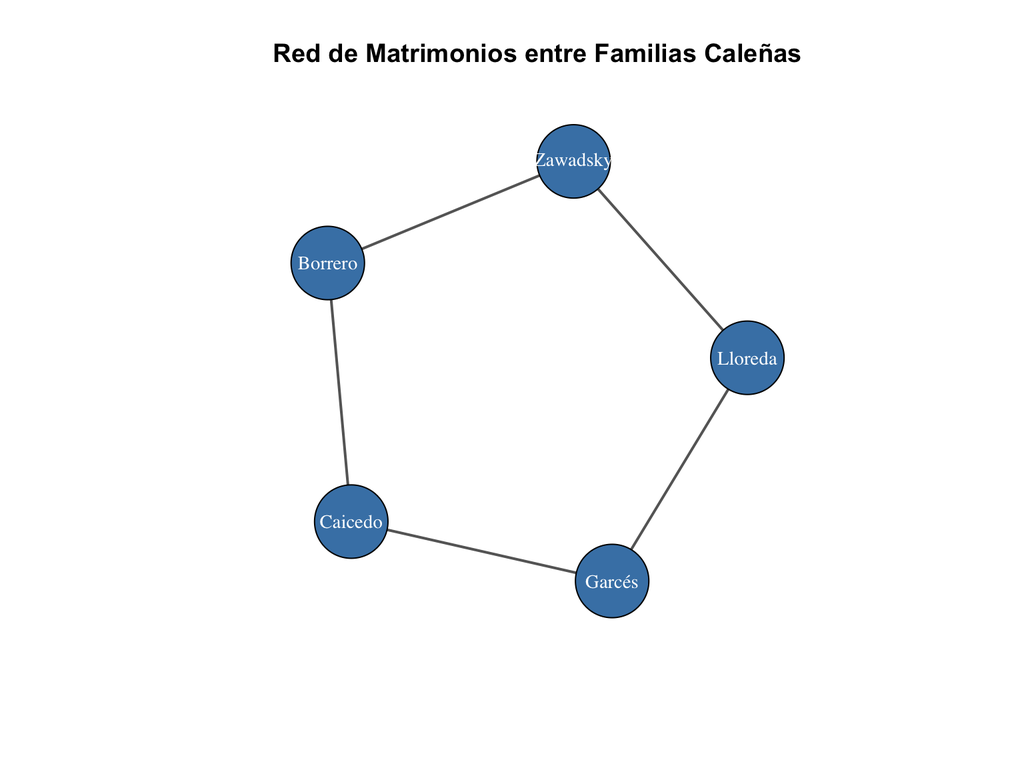

```r
# Fijar semilla para que el gráfico sea reproducible
set.seed(42)

plot(g_matrimonios,
     vertex.color = "steelblue",
     vertex.size = 35,
     vertex.label.color = "white",
     vertex.label.cex = 0.9,
     edge.color = "gray40",
     edge.width = 2,
     main = "Red de Matrimonios entre Familias Caleñas")
```

> **Para tu proyecto:** independientemente de su grupo, el flujo siempre es el mismo: definir nodos, definir vínculos, crear el grafo, visualizar. Lo que cambia es *qué* representan los nodos y los vínculos.

# 4 Dirección Importa — Grafos Dirigidos

No todas las relaciones son simétricas. Un matrimonio conecta a dos familias sin dirección, pero un crédito tiene dirección: alguien **presta** y alguien **recibe**.

## 4.1 Crear un grafo dirigido

```r
# Relaciones de crédito: prestamista -> prestatario
creditos <- matrix(c(
  "Garcés",   "Borrero",
  "Caicedo",  "Zawadsky",
  "Lloreda",  "Garcés",
  "Borrero",  "Caicedo",
  "Lloreda",  "Zawadsky"
), byrow = TRUE, ncol = 2)

# directed = TRUE indica que la dirección importa
g_creditos <- graph_from_edgelist(creditos, directed = TRUE)
```

## 4.2 Grado de entrada vs grado de salida

En un grafo dirigido, cada nodo tiene dos tipos de grado:

- **Grado de salida** (*out-degree*): ¿cuántos créditos otorga?
- **Grado de entrada** (*in-degree*): ¿cuántos créditos recibe?

```r
# Grado de salida: ¿quién presta más?
cat("Grado de salida (créditos otorgados):\n")
```

```
## Grado de salida (créditos otorgados):
```

```r
print(degree(g_creditos, mode = "out"))
```

```
##   Garcés  Borrero  Caicedo Zawadsky  Lloreda
##        1        1        1        0        2
```

```r
# Grado de entrada: ¿quién recibe más?
cat("\nGrado de entrada (créditos recibidos):\n")
```

```
##
## Grado de entrada (créditos recibidos):
```

```r
print(degree(g_creditos, mode = "in"))
```

```
##   Garcés  Borrero  Caicedo Zawadsky  Lloreda
##        1        1        1        2        0
```

## 4.3 Comparación visual

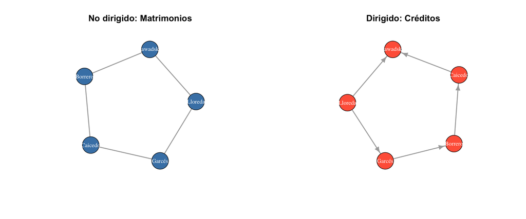

```r
par(mfrow = c(1, 2))
set.seed(42)

# No dirigido (matrimonios)
plot(g_matrimonios,
     vertex.color = "steelblue",
     vertex.size = 30,
     vertex.label.color = "white",
     vertex.label.cex = 0.8,
     edge.width = 2,
     main = "No dirigido: Matrimonios")

# Dirigido (créditos)
plot(g_creditos,
     vertex.color = "tomato",
     vertex.size = 30,
     vertex.label.color = "white",
     vertex.label.cex = 0.8,
     edge.width = 2,
     edge.arrow.size = 0.8,
     main = "Dirigido: Créditos")
```

```r
par(mfrow = c(1, 1))
```

> **Para tu proyecto — Grupo A:** los matrimonios son no dirigidos; las relaciones padrino-ahijado son dirigidas. **Grupo B:** compraventa tiene dirección (vendedor → comprador). **Grupo C:** las calles pueden ser de un solo sentido (dirigidas) o doble vía (no dirigidas).

# 5 El Peso de los Vínculos — Grafos Ponderados

Hasta ahora todos los vínculos valían lo mismo. Pero en la vida real no es igual un crédito de $1,000 que uno de $50,000, ni es lo mismo una familia con 3 matrimonios cruzados que una con solo 1.

## 5.1 Crear un grafo ponderado con `graph_from_data_frame()`

`graph_from_data_frame()` es más flexible que `graph_from_edgelist()` porque acepta columnas adicionales como atributos.

```r
# Crear un data frame con los vínculos y sus pesos
vinculos_pond <- data.frame(
  from = c("Garcés", "Caicedo", "Borrero", "Garcés", "Zawadsky",
           "Lloreda", "Garcés", "Caicedo"),
  to   = c("Caicedo", "Borrero", "Zawadsky", "Lloreda", "Lloreda",
           "Borrero", "Zawadsky", "Lloreda"),
  peso = c(3, 1, 2, 2, 1, 1, 4, 1),
  tipo = c("matrimonio", "matrimonio", "matrimonio", "matrimonio",
           "matrimonio", "crédito", "sociedad", "crédito")
)

# Crear el grafo no dirigido con atributos
g_pond <- graph_from_data_frame(vinculos_pond, directed = FALSE)

# Asignar la columna 'peso' como weight para igraph
E(g_pond)$weight <- E(g_pond)$peso
```

## 5.2 Verificar los pesos

```r
# Ver los atributos de las aristas
cat("Pesos de cada vínculo:\n")
```

```
## Pesos de cada vínculo:
```

```r
print(E(g_pond)$weight)
```

```
## [1] 3 1 2 2 1 1 4 1
```

```r
# Ver el tipo de cada vínculo
cat("\nTipo de cada vínculo:\n")
```

```
##
## Tipo de cada vínculo:
```

```r
print(E(g_pond)$tipo)
```

```
## [1] "matrimonio" "matrimonio" "matrimonio" "matrimonio" "matrimonio"
## [6] "crédito"    "sociedad"   "crédito"
```

## 5.3 Visualizar con grosor proporcional al peso

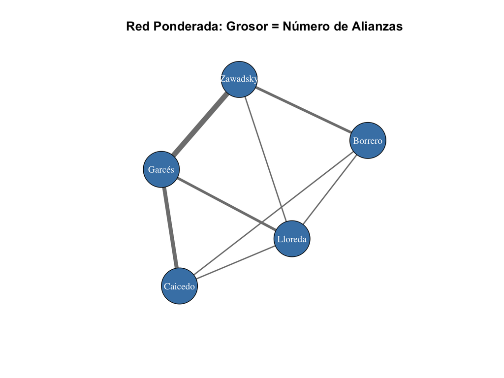

```r
set.seed(42)

plot(g_pond,
     vertex.color = "steelblue",
     vertex.size = 35,
     vertex.label.color = "white",
     vertex.label.cex = 0.9,
     edge.width = E(g_pond)$weight * 2,
     edge.color = "gray50",
     main = "Red Ponderada: Grosor = Número de Alianzas")
```

## 5.4 La fuerza de los lazos débiles

Mark Granovetter (1973) demostró algo contraintuitivo: los vínculos **débiles** (con poco peso, poco frecuentes) a menudo son los más importantes para transmitir información nueva. ¿Por qué? Porque los lazos fuertes tienden a conectar personas que ya se conocen entre sí, mientras que los lazos débiles nos conectan con círculos sociales diferentes.

> **Para tu proyecto:** cuando construyan su red ponderada, piensen: ¿un vínculo fuerte (muchas transacciones, matrimonios repetidos) significa más influencia? ¿O los vínculos débiles revelan puentes entre grupos que de otra forma estarían desconectados?

# 6 La Red como Matriz — Matrices de Adyacencia

Toda red se puede representar como una **matriz de adyacencia**: una tabla cuadrada donde las filas y columnas son los nodos, y cada celda indica si hay un vínculo (y con qué peso).

## 6.1 Matriz sin pesos

```r
# Matriz binaria (1 = hay vínculo, 0 = no hay)
adj_bin <- as_adjacency_matrix(g_matrimonios, sparse = FALSE)
print(adj_bin)
```

```
##          Garcés Caicedo Borrero Zawadsky Lloreda
## Garcés        0       1       0        0       1
## Caicedo       1       0       1        0       0
## Borrero       0       1       0        1       0
## Zawadsky      0       0       1        0       1
## Lloreda       1       0       0        1       0
```

Noten que la matriz es **simétrica** porque el grafo es no dirigido.

## 6.2 Matriz con pesos

```r
# Matriz ponderada
adj_pond <- as_adjacency_matrix(g_pond, attr = "weight", sparse = FALSE)
print(adj_pond)
```

```
##          Garcés Caicedo Borrero Zawadsky Lloreda
## Garcés        0       3       0        4       2
## Caicedo       3       0       1        0       1
## Borrero       0       1       0        2       1
## Zawadsky      4       0       2        0       1
## Lloreda       2       1       1        1       0
```

## 6.3 Redes bipartitas: personas y clubes

Una red **bipartita** tiene dos tipos de nodos. Por ejemplo: **personas** y **clubes sociales**. Solo hay vínculos entre tipos (una persona pertenece a un club), nunca dentro del mismo tipo.

```r
# Definir membresías: persona -> club
membresias <- data.frame(
  persona = c("Garcés", "Garcés", "Caicedo", "Borrero", "Borrero",
              "Zawadsky", "Lloreda", "Lloreda", "Caicedo"),
  club = c("Club Colombia", "Club Campestre", "Club Colombia",
           "Club Colombia", "Club Campestre", "Club Campestre",
           "Club Colombia", "Club Campestre", "Club Campestre")
)

# Crear grafo bipartito
g_bip <- graph_from_data_frame(membresias, directed = FALSE)

# Marcar el tipo de cada nodo (TRUE = club, FALSE = persona)
V(g_bip)$type <- V(g_bip)$name %in% c("Club Colombia", "Club Campestre")

# Verificar
cat("¿Es bipartito?", is_bipartite(g_bip), "\n")
```

```
## ¿Es bipartito? TRUE
```

## 6.4 Proyección: de bipartito a persona-persona

La **proyección** convierte la red bipartita en una red donde solo quedan las personas, conectadas si comparten al menos un club. Este es el procedimiento clásico de Breiger (1974): la **dualidad de personas y grupos**.

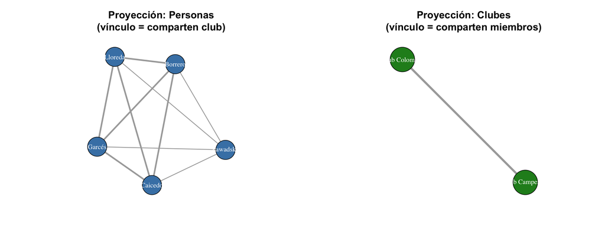

```r
# Proyectar
proyecciones <- bipartite_projection(g_bip)
g_personas <- proyecciones$proj1  # proyección de personas
g_clubes <- proyecciones$proj2    # proyección de clubes

par(mfrow = c(1, 2))
set.seed(42)

# Red persona-persona (co-membresía)
plot(g_personas,
     vertex.color = "steelblue",
     vertex.size = 30,
     vertex.label.color = "white",
     vertex.label.cex = 0.8,
     edge.width = E(g_personas)$weight * 1.5,
     main = "Proyección: Personas\n(vínculo = comparten club)")

# Red club-club
plot(g_clubes,
     vertex.color = "forestgreen",
     vertex.size = 40,
     vertex.label.color = "white",
     vertex.label.cex = 0.8,
     edge.width = E(g_clubes)$weight,
     main = "Proyección: Clubes\n(vínculo = comparten miembros)")
```

```r
par(mfrow = c(1, 1))
```

> **Para tu proyecto — Grupo A:** Breiger (1974) es su referencia metodológica central. Sus datos de membresías en clubes y juntas directivas son exactamente una red bipartita que deben proyectar para obtener la red social persona-persona.

# 7 El Grado

El **grado** de un nodo es simplemente cuántos vínculos tiene. Es la medida más básica pero ya nos dice mucho: un nodo con muchos vínculos es un actor muy conectado.

## 7.1 Red más grande para trabajar

Vamos a crear una red sintética de ~20 actores caleños que usaremos también en las secciones siguientes.

```r
set.seed(123)

# Actores ficticios (apellidos de familias caleñas)
actores <- c("Garcés", "Caicedo", "Borrero", "Zawadsky", "Lloreda",
             "Eder", "Sardi", "Carvajal", "Ochoa", "Valencia",
             "Domínguez", "Guerrero", "Holguín", "Isaacs", "Lozano",
             "Mercado", "Navia", "Orejuela", "Palau", "Quintero")

# Generar vínculos aleatorios pero con estructura realista
# Usamos un modelo donde las primeras 5 familias (élite) tienen más conexiones
vinculos_red <- data.frame(from = character(), to = character(),
                           stringsAsFactors = FALSE)

# Las familias de élite se conectan mucho entre sí
elite <- actores[1:5]
for (i in 1:(length(elite)-1)) {
  for (j in (i+1):length(elite)) {
    vinculos_red <- rbind(vinculos_red,
                          data.frame(from = elite[i], to = elite[j]))
  }
}

# Conexiones entre élite y otros actores
set.seed(42)
for (e in elite) {
  n_conexiones <- sample(2:4, 1)
  otros <- sample(actores[6:20], n_conexiones)
  for (o in otros) {
    vinculos_red <- rbind(vinculos_red, data.frame(from = e, to = o))
  }
}

# Algunas conexiones entre actores no-élite
for (i in 1:8) {
  par_nodos <- sample(actores[6:20], 2)
  vinculos_red <- rbind(vinculos_red,
                        data.frame(from = par_nodos[1], to = par_nodos[2]))
}

# Eliminar duplicados
vinculos_red <- unique(vinculos_red)

# Crear el grafo
g_cali <- graph_from_data_frame(vinculos_red, directed = FALSE, vertices = data.frame(name = actores))
g_cali <- simplify(g_cali)

cat("Red de Cali:", vcount(g_cali), "nodos,", ecount(g_cali), "vínculos\n")
```

```
## Red de Cali: 20 nodos, 31 vínculos
```

## 7.2 Calcular el grado

```r
# Grado de cada nodo
grados <- degree(g_cali)

# Ordenar de mayor a menor
grados_ord <- sort(grados, decreasing = TRUE)
print(grados_ord)
```

```
##  Zawadsky   Borrero   Lloreda    Garcés   Caicedo    Lozano      Eder     Ochoa
##         8         7         7         6         6         4         3         3
##  Valencia   Holguín    Isaacs     Sardi  Carvajal  Quintero   Mercado     Navia
##         3         3         3         2         2         2         1         1
##  Orejuela Domínguez  Guerrero     Palau
##         1         0         0         0
```

## 7.3 Distribución de grado

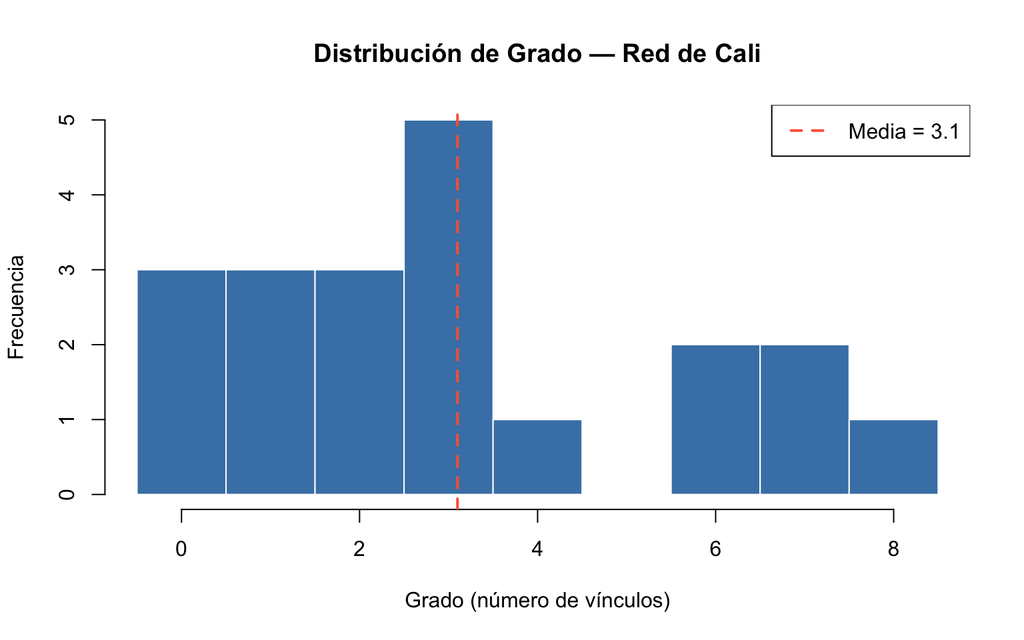

```r
hist(grados,
     breaks = seq(min(grados) - 0.5, max(grados) + 0.5, by = 1),
     col = "steelblue",
     border = "white",
     main = "Distribución de Grado — Red de Cali",
     xlab = "Grado (número de vínculos)",
     ylab = "Frecuencia")
abline(v = mean(grados), col = "tomato", lwd = 2, lty = 2)
legend("topright", legend = paste("Media =", round(mean(grados), 1)),
       col = "tomato", lwd = 2, lty = 2)
```

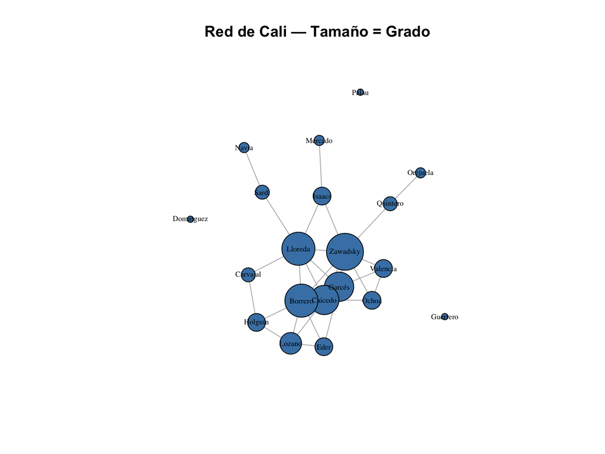

```r
# Visualizar la red con tamaño proporcional al grado
set.seed(42)

plot(g_cali,
     vertex.size = grados * 3 + 5,
     vertex.color = "steelblue",
     vertex.label.cex = 0.6,
     vertex.label.color = "black",
     edge.color = "gray70",
     main = "Red de Cali — Tamaño = Grado")
```

> **Para tu proyecto:** el grado es su primera medida de importancia. ¿Qué familia tiene más matrimonios (Grupo A)? ¿Qué actor participa en más transacciones (Grupo B)? ¿Qué intersección conecta más calles (Grupo C)?

# 8 Caminos, Distancias y Diámetro

## 8.1 Caminos más cortos

Un **camino** es una secuencia de nodos conectados por vínculos. El **camino más corto** entre dos nodos es el que usa menos vínculos (o menor peso total).

```r
# Camino más corto entre Quintero y Garcés
camino <- shortest_paths(g_cali, from = "Quintero", to = "Garcés")$vpath[[1]]
cat("Camino más corto de Quintero a Garcés:\n")
```

```
## Camino más corto de Quintero a Garcés:
```

```r
cat(paste(V(g_cali)$name[camino], collapse = " → "), "\n")
```

```
## Quintero → Zawadsky → Garcés
```

```r
cat("Longitud:", length(camino) - 1, "pasos\n")
```

```
## Longitud: 2 pasos
```

## 8.2 Matriz de distancias

```r
# Distancias entre todos los pares de nodos
dist_matrix <- distances(g_cali)

# Mostrar solo las primeras 6 familias
print(dist_matrix[1:6, 1:6])
```

```
##          Garcés Caicedo Borrero Zawadsky Lloreda Eder
## Garcés        0       1       1        1       1    1
## Caicedo       1       0       1        1       1    2
## Borrero       1       1       0        1       1    1
## Zawadsky      1       1       1        0       1    2
## Lloreda       1       1       1        1       0    2
## Eder          1       2       1        2       2    0
```

## 8.3 Diámetro y distancia media

```r
# Diámetro: el camino más corto más largo
cat("Diámetro de la red:", diameter(g_cali), "\n")
```

```
## Diámetro de la red: 5
```

```r
# Distancia media
cat("Distancia media:", round(mean_distance(g_cali), 2), "\n")
```

```
## Distancia media: 2.33
```

```r
# ¿La red es conexa? (todos los nodos se pueden alcanzar entre sí)
cat("¿Es conexa?", is_connected(g_cali), "\n")
```

```
## ¿Es conexa? FALSE
```

## 8.4 Visualizar el camino más corto

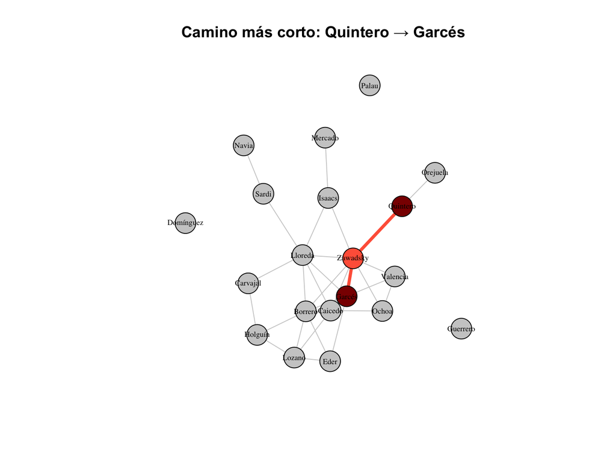

```r
set.seed(42)

# Colores: resaltar nodos y aristas del camino
colores_nodos <- rep("gray80", vcount(g_cali))
colores_nodos[camino] <- "tomato"
colores_nodos[camino[1]] <- "darkred"
colores_nodos[camino[length(camino)]] <- "darkred"

# Identificar aristas del camino
aristas_camino <- rep("gray80", ecount(g_cali))
anchos_aristas <- rep(1, ecount(g_cali))
for (k in 1:(length(camino) - 1)) {
  eid <- get.edge.ids(g_cali, c(camino[k], camino[k + 1]))
  if (eid > 0) {
    aristas_camino[eid] <- "tomato"
    anchos_aristas[eid] <- 4
  }
}

plot(g_cali,
     vertex.size = 15,
     vertex.color = colores_nodos,
     vertex.label.cex = 0.6,
     vertex.label.color = "black",
     edge.color = aristas_camino,
     edge.width = anchos_aristas,
     main = "Camino más corto: Quintero → Garcés")
```

> **Para tu proyecto:** la distancia entre dos actores mide cuántos intermediarios necesitan para conectarse. Si la red no es conexa, hay grupos completamente aislados — eso también es un hallazgo importante.

# 9 Centralidad

No todos los nodos son igualmente “importantes”. Hay varias formas de medir la importancia, y cada una captura algo diferente.

## 9.1 Centralidad de Grado

Ya la conocemos: ¿cuántos vínculos tiene un nodo? La versión **normalizada** divide por el máximo posible (n-1).

```r
cent_grado <- degree(g_cali, normalized = TRUE)
cat("Centralidad de grado (normalizada):\n")
```

```
## Centralidad de grado (normalizada):
```

```r
print(round(sort(cent_grado, decreasing = TRUE), 3))
```

```
##  Zawadsky   Borrero   Lloreda    Garcés   Caicedo    Lozano      Eder     Ochoa
##     0.421     0.368     0.368     0.316     0.316     0.211     0.158     0.158
##  Valencia   Holguín    Isaacs     Sardi  Carvajal  Quintero   Mercado     Navia
##     0.158     0.158     0.158     0.105     0.105     0.105     0.053     0.053
##  Orejuela Domínguez  Guerrero     Palau
##     0.053     0.000     0.000     0.000
```

## 9.2 Centralidad de Intermediación (*Betweenness*)

¿Cuántos caminos más cortos pasan por un nodo? Un nodo con alta intermediación es un **broker** o **gatekeeper**: controla el flujo de información o recursos entre partes de la red.

Padgett & McLean (2006) mostraron que los Medici en la Florencia del siglo XV tenían una posición de intermediación excepcional: no eran la familia con más vínculos, pero eran el puente entre facciones rivales. Esta es la misma lógica que pueden aplicar a las familias caleñas.

```r
cent_betw <- betweenness(g_cali, normalized = TRUE)
cat("Centralidad de intermediación (normalizada):\n")
```

```
## Centralidad de intermediación (normalizada):
```

```r
print(round(sort(cent_betw, decreasing = TRUE), 3))
```

```
##  Zawadsky   Lloreda   Borrero     Sardi    Isaacs  Quintero    Garcés   Caicedo
##     0.262     0.259     0.113     0.088     0.088     0.088     0.058     0.058
##  Carvajal    Lozano   Holguín      Eder     Ochoa  Valencia Domínguez  Guerrero
##     0.013     0.012     0.012     0.003     0.003     0.003     0.000     0.000
##   Mercado     Navia  Orejuela     Palau
##     0.000     0.000     0.000     0.000
```

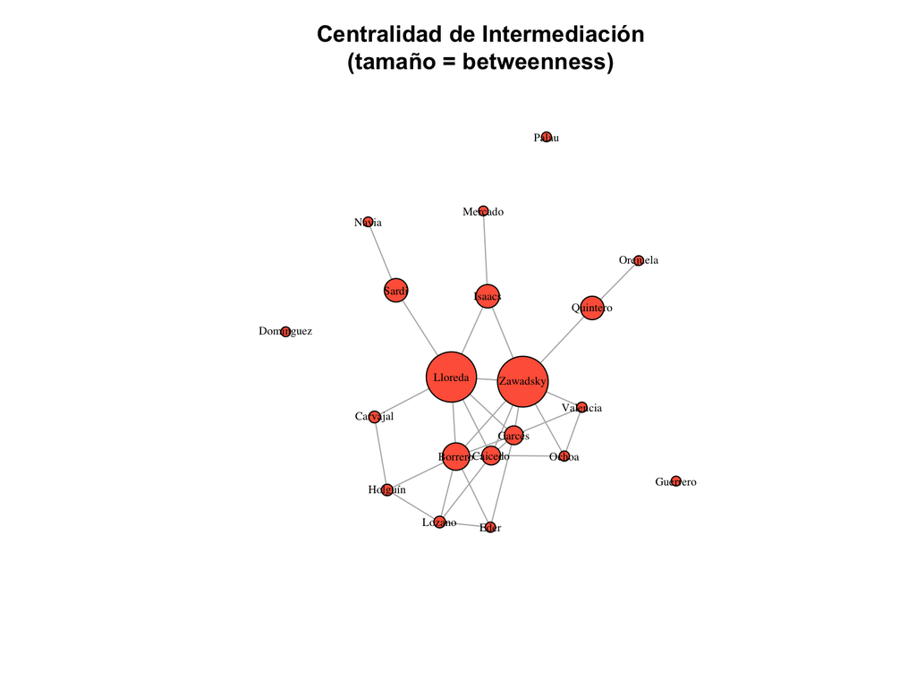

```r
set.seed(42)

plot(g_cali,
     vertex.size = cent_betw * 80 + 5,
     vertex.color = "tomato",
     vertex.label.cex = 0.6,
     vertex.label.color = "black",
     edge.color = "gray70",
     main = "Centralidad de Intermediación\n(tamaño = betweenness)")
```

## 9.3 Centralidad de Vector Propio (*Eigenvector Centrality*)

“No importa solo cuántas conexiones tienes, sino **a quién** estás conectado.” Un nodo tiene alta centralidad de vector propio si está conectado a nodos que a su vez están muy conectados.

```r
cent_eigen <- eigen_centrality(g_cali)$vector
cat("Centralidad de vector propio:\n")
```

```
## Centralidad de vector propio:
```

```r
print(round(sort(cent_eigen, decreasing = TRUE), 3))
```

```
##  Zawadsky   Borrero   Caicedo    Garcés   Lloreda    Lozano      Eder     Ochoa
##     1.000     0.971     0.916     0.907     0.886     0.519     0.463     0.459
##  Valencia    Isaacs   Holguín  Carvajal  Quintero     Sardi   Mercado  Orejuela
##     0.457     0.379     0.333     0.236     0.201     0.178     0.073     0.039
##     Navia Domínguez  Guerrero     Palau
##     0.034     0.000     0.000     0.000
```

## 9.4 Tabla comparativa

```r
# Crear tabla comparativa
tabla_cent <- data.frame(
  Nodo = V(g_cali)$name,
  Grado = round(cent_grado, 3),
  Intermediación = round(cent_betw, 3),
  Vector_Propio = round(cent_eigen, 3)
)

# Ordenar por grado
tabla_cent <- tabla_cent[order(-tabla_cent$Grado), ]
rownames(tabla_cent) <- NULL

knitr::kable(tabla_cent,
             col.names = c("Nodo", "Grado", "Intermediación", "Vector Propio"),
             caption = "Comparación de centralidades — Red de Cali")
```

Comparación de centralidades — Red de Cali

| Nodo | Grado | Intermediación | Vector Propio |
| --- | --- | --- | --- |
| Zawadsky | 0.421 | 0.262 | 1.000 |
| Borrero | 0.368 | 0.113 | 0.971 |
| Lloreda | 0.368 | 0.259 | 0.886 |
| Garcés | 0.316 | 0.058 | 0.907 |
| Caicedo | 0.316 | 0.058 | 0.916 |
| Lozano | 0.211 | 0.012 | 0.519 |
| Eder | 0.158 | 0.003 | 0.463 |
| Ochoa | 0.158 | 0.003 | 0.459 |
| Valencia | 0.158 | 0.003 | 0.457 |
| Holguín | 0.158 | 0.012 | 0.333 |
| Isaacs | 0.158 | 0.088 | 0.379 |
| Sardi | 0.105 | 0.088 | 0.178 |
| Carvajal | 0.105 | 0.013 | 0.236 |
| Quintero | 0.105 | 0.088 | 0.201 |
| Mercado | 0.053 | 0.000 | 0.073 |
| Navia | 0.053 | 0.000 | 0.034 |
| Orejuela | 0.053 | 0.000 | 0.039 |
| Domínguez | 0.000 | 0.000 | 0.000 |
| Guerrero | 0.000 | 0.000 | 0.000 |
| Palau | 0.000 | 0.000 | 0.000 |

Observen: el nodo con mayor grado no necesariamente es el de mayor intermediación. Cada métrica cuenta una historia diferente.

> **Para tu proyecto:** usen al menos dos medidas de centralidad y comparen los rankings. ¿El actor más conectado (grado) es también el mejor broker (intermediación)? Si no, ¿qué significa eso para su pregunta de investigación?

# 10 Clustering y Comunidades

## 10.1 Coeficiente de Clustering (Transitividad)

El **coeficiente de clustering** mide qué tan conectados están los vecinos de un nodo entre sí. Si yo conozco a A y a B, ¿A y B se conocen? Un clustering alto indica que la red tiene muchos triángulos (grupos cerrados).

```r
# Clustering global (proporción de triángulos cerrados en toda la red)
cat("Clustering global:", round(transitivity(g_cali, type = "global"), 3), "\n")
```

```
## Clustering global: 0.435
```

```r
# Clustering local de cada nodo
clust_local <- transitivity(g_cali, type = "local")
names(clust_local) <- V(g_cali)$name

cat("\nClustering local (primeros 10):\n")
```

```
##
## Clustering local (primeros 10):
```

```r
print(round(sort(clust_local, decreasing = TRUE, na.last = TRUE)[1:10], 3))
```

```
##     Eder    Ochoa Valencia   Garcés  Caicedo   Lozano  Borrero Zawadsky
##    0.667    0.667    0.667    0.533    0.533    0.500    0.476    0.357
##  Lloreda  Holguín
##    0.333    0.333
```

## 10.2 Detección de Comunidades

Una **comunidad** es un grupo de nodos que están más densamente conectados entre sí que con el resto de la red. El algoritmo de Louvain encuentra estas comunidades maximizando la **modularidad**.

```r
# Detectar comunidades con el algoritmo de Louvain
set.seed(42)
comunidades <- cluster_louvain(g_cali)

# Resultados
cat("Número de comunidades encontradas:", length(comunidades), "\n")
```

```
## Número de comunidades encontradas: 7
```

```r
cat("Modularidad:", round(modularity(comunidades), 3), "\n")
```

```
## Modularidad: 0.293
```

```r
# ¿Quién pertenece a cada comunidad?
for (i in 1:length(comunidades)) {
  cat(paste0("\nComunidad ", i, ": "))
  cat(paste(V(g_cali)$name[membership(comunidades) == i], collapse = ", "), "\n")
}
```

```
##
## Comunidad 1: Garcés, Caicedo, Zawadsky, Ochoa, Valencia
##
## Comunidad 2: Borrero, Eder, Holguín, Lozano
##
## Comunidad 3: Lloreda, Sardi, Carvajal, Isaacs, Mercado, Navia
##
## Comunidad 4: Domínguez
##
## Comunidad 5: Guerrero
##
## Comunidad 6: Orejuela, Quintero
##
## Comunidad 7: Palau
```

## 10.3 Visualizar comunidades

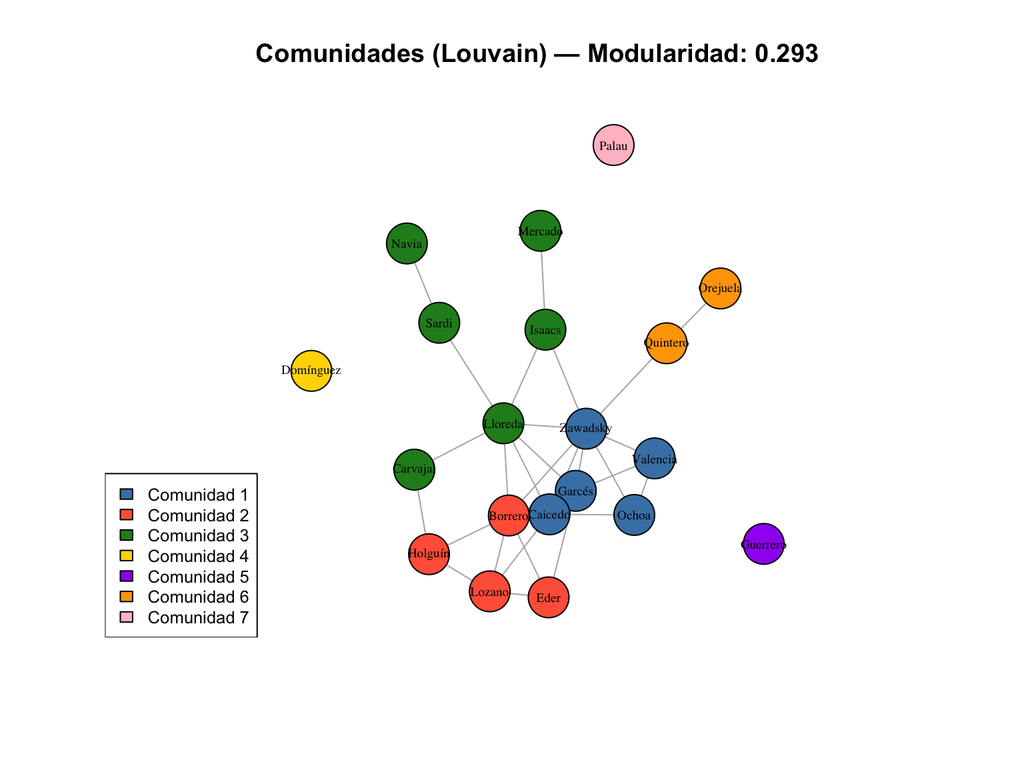

```r
set.seed(42)

# Colores por comunidad
colores_com <- c("steelblue", "tomato", "forestgreen", "gold",
                 "purple", "orange", "pink", "cyan")[membership(comunidades)]

plot(g_cali,
     vertex.size = 18,
     vertex.color = colores_com,
     vertex.label.cex = 0.6,
     vertex.label.color = "black",
     edge.color = "gray70",
     main = paste("Comunidades (Louvain) — Modularidad:",
                  round(modularity(comunidades), 3)))

legend("bottomleft",
       legend = paste("Comunidad", 1:length(comunidades)),
       fill = c("steelblue", "tomato", "forestgreen", "gold",
                "purple", "orange", "pink", "cyan")[1:length(comunidades)],
       cex = 0.8)
```

> **Para tu proyecto:** la detección de comunidades les permitirá identificar facciones, barrios o clusters económicos en Cali. ¿Las comunidades detectadas coinciden con lo que saben de la historia? Si no, ¿qué les dice el algoritmo que la historiografía no había visto?

# 11 Mundos Pequeños y Redes de Escala Libre

Ahora pasamos de redes empíricas a **modelos teóricos**: estructuras idealizadas que nos ayudan a entender las propiedades de las redes reales.

## 11.1 Mundos Pequeños (Watts-Strogatz)

En 1998, Watts y Strogatz descubrieron que muchas redes reales tienen dos propiedades simultáneas:

1. **Clustering alto:** mis amigos tienden a ser amigos entre sí.
2. **Distancia media baja:** puedo llegar a cualquiera en pocos pasos.

Esto es el fenómeno de los “seis grados de separación”.

```r
set.seed(42)

# Parámetros
n <- 50         # número de nodos
nei <- 4        # vecinos iniciales (a cada lado)
p_rewire <- 0.1 # probabilidad de reconexión

# Crear red de mundo pequeño
g_sw <- sample_smallworld(dim = 1, size = n, nei = nei, p = p_rewire)

# Crear red aleatoria Erdős-Rényi con la misma densidad para comparar
g_er <- sample_gnm(n = n, m = ecount(g_sw))

# Comparar propiedades
comparacion <- data.frame(
  Propiedad = c("Clustering global", "Distancia media"),
  Watts_Strogatz = c(
    round(transitivity(g_sw, type = "global"), 3),
    round(mean_distance(g_sw), 3)
  ),
  Erdos_Renyi = c(
    round(transitivity(g_er, type = "global"), 3),
    round(mean_distance(g_er), 3)
  )
)

knitr::kable(comparacion,
             caption = "Comparación: Mundo Pequeño vs Red Aleatoria")
```

Comparación: Mundo Pequeño vs Red Aleatoria

| Propiedad | Watts_Strogatz | Erdos_Renyi |
| --- | --- | --- |
| Clustering global | 0.377 | 0.160 |
| Distancia media | 2.309 | 2.077 |

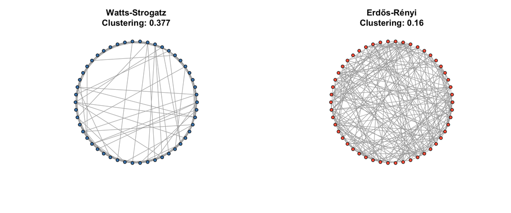

```r
par(mfrow = c(1, 2))

plot(g_sw, vertex.size = 5, vertex.label = NA,
     vertex.color = "steelblue",
     layout = layout_in_circle,
     main = paste("Watts-Strogatz\nClustering:",
                  round(transitivity(g_sw, type = "global"), 3)))

plot(g_er, vertex.size = 5, vertex.label = NA,
     vertex.color = "tomato",
     layout = layout_in_circle,
     main = paste("Erdős-Rényi\nClustering:",
                  round(transitivity(g_er, type = "global"), 3)))
```

```r
par(mfrow = c(1, 1))
```

## 11.2 Redes de Escala Libre (Barabási-Albert)

En 1999, Barabási y Albert descubrieron que muchas redes reales siguen un principio de **conexión preferencial** (*preferential attachment*): los nodos que ya tienen muchos vínculos tienden a atraer aún más vínculos. “Los ricos se hacen más ricos.”

Esto produce una **distribución de grado de ley de potencia**: la mayoría de nodos tiene pocas conexiones, pero unos pocos *hubs* tienen muchísimas.

```r
set.seed(42)

# Crear red de Barabási-Albert
g_ba <- sample_pa(n = 200, m = 2, directed = FALSE)

# Distribución de grado
grados_ba <- degree(g_ba)

cat("Grado máximo:", max(grados_ba), "\n")
```

```
## Grado máximo: 27
```

```r
cat("Grado medio:", round(mean(grados_ba), 2), "\n")
```

```
## Grado medio: 3.97
```

```r
cat("Grado mediano:", median(grados_ba), "\n")
```

```
## Grado mediano: 3
```

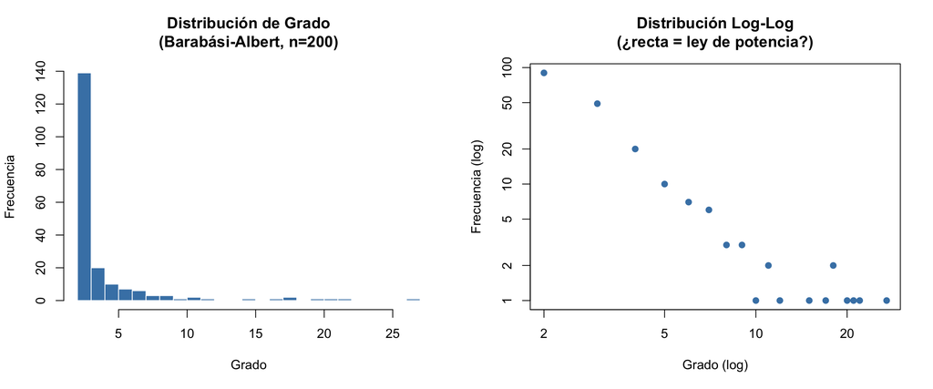

```r
par(mfrow = c(1, 2))

# Distribución de grado (histograma normal)
hist(grados_ba, breaks = 30, col = "steelblue", border = "white",
     main = "Distribución de Grado\n(Barabási-Albert, n=200)",
     xlab = "Grado", ylab = "Frecuencia")

# Distribución de grado en escala log-log
grado_tabla <- table(grados_ba)
plot(as.numeric(names(grado_tabla)), as.numeric(grado_tabla),
     log = "xy", pch = 19, col = "steelblue",
     xlab = "Grado (log)", ylab = "Frecuencia (log)",
     main = "Distribución Log-Log\n(¿recta = ley de potencia?)")
```

```r
par(mfrow = c(1, 1))
```

```r
# Ajustar ley de potencia
ajuste <- fit_power_law(grados_ba)
cat("Exponente estimado (alpha):", round(ajuste$alpha, 2), "\n")
```

```
## Exponente estimado (alpha): 2.71
```

```r
cat("Grado mínimo (xmin):", ajuste$xmin, "\n")
```

```
## Grado mínimo (xmin): 3
```

> **Para tu proyecto:** ¿la red que están construyendo se parece más a un mundo pequeño o a una red de escala libre? Calculen clustering, distancia media y vean la distribución de grado. La respuesta les dirá algo sobre cómo se organizaba la sociedad caleña.

# 12 De los Datos Reales a la Red

Esta es la sección más práctica: cómo pasar de archivos de datos a una red lista para analizar.

## 12.1 Estructura de datos recomendada

Necesitan **dos archivos CSV**:

### 12.1.1 Edge list (lista de vínculos)

| Columna | Descripción | Ejemplo (Grupo A) | Ejemplo (Grupo B) | Ejemplo (Grupo C) |
| --- | --- | --- | --- | --- |
| `origen` | Nodo de origen | Garcés | Garcés | Calle 5/Cra 1 |
| `destino` | Nodo de destino | Caicedo | Caicedo | Calle 5/Cra 2 |
| `tipo_vinculo` | Tipo de relación | matrimonio | compraventa | calle |
| `peso` | Intensidad | 1 | 12000 | 150 (metros) |
| `año` | Fecha | 1912 | 1920 | 1930 |
| `fuente` | Archivo/documento | Registro Civil | Notaría Primera | Plano 1930 |

### 12.1.2 Node list (lista de actores)

| Columna | Descripción | Ejemplo |
| --- | --- | --- |
| `id` | Identificador único | 1 |
| `nombre` | Nombre del actor | Jorge |
| `apellido` | Apellido | Garcés |
| `tipo` | Categoría | familia_elite |
| `fuente` | Documento fuente | Registro Civil |

## 12.2 Leer los CSV y crear la red

Vamos a leer los archivos de ejemplo que acompañan esta clase.

```r
# Leer los CSV con encoding UTF-8 (importante para acentos y ñ)
vinculos <- read.csv("vinculos_ejemplo.csv", fileEncoding = "UTF-8",
                     stringsAsFactors = FALSE)
actores <- read.csv("actores_ejemplo.csv", fileEncoding = "UTF-8",
                    stringsAsFactors = FALSE)

# Revisar las primeras filas
cat("=== Vínculos ===\n")
```

```
## === Vínculos ===
```

```r
print(head(vinculos))
```

```
##     origen  destino tipo_vinculo peso  año          fuente
## 1   Garcés  Caicedo   matrimonio    1 1912  Registro Civil
## 2  Caicedo  Borrero   matrimonio    1 1918  Registro Civil
## 3  Borrero Zawadsky   matrimonio    1 1925  Registro Civil
## 4   Garcés  Lloreda   matrimonio    1 1930  Registro Civil
## 5 Zawadsky  Lloreda   matrimonio    1 1935  Registro Civil
## 6   Garcés  Borrero      crédito 5000 1920 Notaría Primera
```

```r
cat("\n=== Actores ===\n")
```

```
##
## === Actores ===
```

```r
print(head(actores))
```

```
##   id   nombre apellido          tipo          fuente
## 1  1    Jorge   Garcés familia_elite  Registro Civil
## 2  2  Roberto  Caicedo familia_elite  Registro Civil
## 3  3  Ernesto  Borrero familia_elite  Registro Civil
## 4  4  Alfredo Zawadsky familia_elite  Registro Civil
## 5  5   Álvaro  Lloreda familia_elite  Registro Civil
## 6  6 Hernando     Eder     hacendado Notaría Primera
```

```r
# Crear el grafo desde los data frames
# Usamos las columnas 'origen' y 'destino' del edge list
# y la columna 'apellido' del node list como identificador
g_datos <- graph_from_data_frame(
  d = vinculos[, c("origen", "destino", "tipo_vinculo", "peso", "año", "fuente")],
  directed = FALSE,
  vertices = actores[, c("apellido", "nombre", "tipo", "fuente")]
)

cat("Red creada:", vcount(g_datos), "nodos,", ecount(g_datos), "vínculos\n")
```

```
## Red creada: 11 nodos, 18 vínculos
```

## 12.3 Validación

Antes de analizar, siempre hay que validar los datos.

```r
# ¿El grafo es simple? (sin lazos ni aristas múltiples)
cat("¿Es simple?", is_simple(g_datos), "\n")
```

```
## ¿Es simple? FALSE
```

```r
# Si no es simple, ¿cuántas aristas múltiples hay?
cat("Aristas múltiples:", sum(which_multiple(g_datos)), "\n")
```

```
## Aristas múltiples: 8
```

```r
cat("Lazos (self-loops):", sum(which_loop(g_datos)), "\n")
```

```
## Lazos (self-loops): 0
```

```r
# ¿Hay nodos aislados (sin vínculos)?
grados_datos <- degree(g_datos)
aislados <- V(g_datos)$name[grados_datos == 0]
if (length(aislados) > 0) {
  cat("Nodos aislados:", paste(aislados, collapse = ", "), "\n")
  cat("(Revisen: ¿son errores de transcripción o actores realmente aislados?)\n")
} else {
  cat("No hay nodos aislados.\n")
}
```

```
## Nodos aislados: Eder, Sardi, Carvajal, Ochoa, Valencia, Domínguez
## (Revisen: ¿son errores de transcripción o actores realmente aislados?)
```

```r
# Componentes conexas
cat("Número de componentes:", components(g_datos)$no, "\n")
```

```
## Número de componentes: 7
```

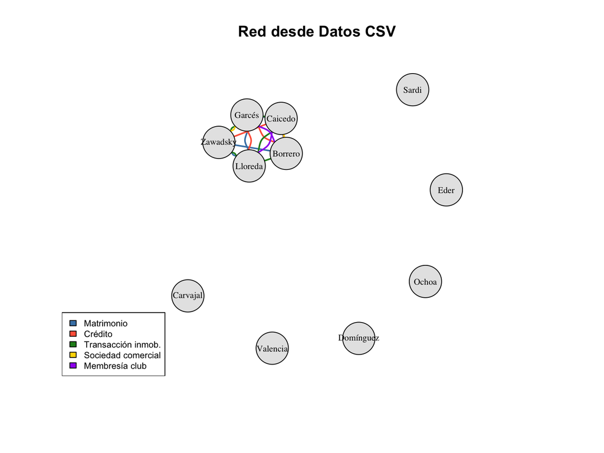

```r
# Visualizar la red construida desde los CSV
set.seed(42)

# Colores por tipo de vínculo
colores_vinc <- ifelse(E(g_datos)$tipo_vinculo == "matrimonio", "steelblue",
                ifelse(E(g_datos)$tipo_vinculo == "crédito", "tomato",
                ifelse(E(g_datos)$tipo_vinculo == "transacción_inmobiliaria", "forestgreen",
                ifelse(E(g_datos)$tipo_vinculo == "sociedad_comercial", "gold", "purple"))))

plot(g_datos,
     vertex.size = 25,
     vertex.color = "gray90",
     vertex.label.cex = 0.7,
     vertex.label.color = "black",
     edge.color = colores_vinc,
     edge.width = 2,
     main = "Red desde Datos CSV")

legend("bottomleft",
       legend = c("Matrimonio", "Crédito", "Transacción inmob.", "Sociedad comercial", "Membresía club"),
       fill = c("steelblue", "tomato", "forestgreen", "gold", "purple"),
       cex = 0.7)
```

## 12.4 Exportar a Gephi

Gephi es un programa de visualización de redes. Para abrir su red en Gephi, expórtenla en formato GraphML.

```r
# Exportar a formato GraphML (compatible con Gephi)
write_graph(g_datos, "red_cali.graphml", format = "graphml")
cat("Archivo exportado: red_cali.graphml\n")
cat("Abrir en Gephi: File > Open > seleccionar red_cali.graphml\n")
```

> **Para tu proyecto:** usen exactamente esta estructura de CSV. Cuando tengan dudas sobre cómo codificar un dato, recuerden: cada fila del edge list es **un vínculo**, cada fila del node list es **un actor**. Mantengan la columna `fuente` siempre llena — es su trazabilidad.

# 13 Resumen y Próximos Pasos

## 13.1 Tabla resumen

```r
resumen <- data.frame(
  Concepto = c(
    "Nodo / Vértice",
    "Vínculo / Arista",
    "Grafo no dirigido",
    "Grafo dirigido",
    "Peso",
    "Matriz de adyacencia",
    "Red bipartita",
    "Grado",
    "Distancia / Camino más corto",
    "Diámetro",
    "Centralidad de grado",
    "Centralidad de intermediación",
    "Centralidad de vector propio",
    "Clustering",
    "Comunidades",
    "Mundo pequeño",
    "Escala libre"
  ),
  Función_igraph = c(
    "vcount(), V()",
    "ecount(), E()",
    "graph_from_edgelist(directed=FALSE)",
    "graph_from_edgelist(directed=TRUE)",
    "E(g)$weight",
    "as_adjacency_matrix()",
    "bipartite_projection()",
    "degree()",
    "shortest_paths(), distances()",
    "diameter()",
    "degree(normalized=TRUE)",
    "betweenness()",
    "eigen_centrality()",
    "transitivity()",
    "cluster_louvain()",
    "sample_smallworld()",
    "sample_pa()"
  ),
  Pregunta_Cali = c(
    "¿Quiénes son los actores relevantes?",
    "¿Qué relaciones los conectan?",
    "¿Quiénes se casaron entre sí?",
    "¿Quién le prestó a quién?",
    "¿Cuántas transacciones hubo?",
    "¿Cómo se ve la red completa en una tabla?",
    "¿Quiénes comparten membresía en clubes?",
    "¿Quién tiene más conexiones?",
    "¿Cuántos pasos hay entre dos actores?",
    "¿Qué tan 'grande' es la red?",
    "¿Quién es el más conectado (normalizado)?",
    "¿Quién es el broker/intermediario clave?",
    "¿Quién está conectado a los poderosos?",
    "¿Los amigos de mis amigos son amigos?",
    "¿Hay facciones o grupos diferenciados?",
    "¿Se puede llegar rápido a cualquiera?",
    "¿Hay unos pocos hubs muy conectados?"
  )
)

knitr::kable(resumen,
             col.names = c("Concepto", "Función igraph", "Pregunta para Cali"),
             caption = "Resumen: conceptos, funciones y preguntas de investigación")
```

Resumen: conceptos, funciones y preguntas de investigación

| Concepto | Función igraph | Pregunta para Cali |
| --- | --- | --- |
| Nodo / Vértice | vcount(), V() | ¿Quiénes son los actores relevantes? |
| Vínculo / Arista | ecount(), E() | ¿Qué relaciones los conectan? |
| Grafo no dirigido | graph_from_edgelist(directed=FALSE) | ¿Quiénes se casaron entre sí? |
| Grafo dirigido | graph_from_edgelist(directed=TRUE) | ¿Quién le prestó a quién? |
| Peso | E(g)$weight | ¿Cuántas transacciones hubo? |
| Matriz de adyacencia | as_adjacency_matrix() | ¿Cómo se ve la red completa en una tabla? |
| Red bipartita | bipartite_projection() | ¿Quiénes comparten membresía en clubes? |
| Grado | degree() | ¿Quién tiene más conexiones? |
| Distancia / Camino más corto | shortest_paths(), distances() | ¿Cuántos pasos hay entre dos actores? |
| Diámetro | diameter() | ¿Qué tan ‘grande’ es la red? |
| Centralidad de grado | degree(normalized=TRUE) | ¿Quién es el más conectado (normalizado)? |
| Centralidad de intermediación | betweenness() | ¿Quién es el broker/intermediario clave? |
| Centralidad de vector propio | eigen_centrality() | ¿Quién está conectado a los poderosos? |
| Clustering | transitivity() | ¿Los amigos de mis amigos son amigos? |
| Comunidades | cluster_louvain() | ¿Hay facciones o grupos diferenciados? |
| Mundo pequeño | sample_smallworld() | ¿Se puede llegar rápido a cualquiera? |
| Escala libre | sample_pa() | ¿Hay unos pocos hubs muy conectados? |

## 13.2 Checklist por grupo — Hito 1 (Semana 4)

### 13.2.1 Grupo A: Red Social

- Edge list con al menos 30 vínculos (matrimonios, parentesco, compadrazgo)
- Node list con todos los actores y su tipo (familia élite, comerciante, etc.)
- Grafo construido en igraph y visualizado
- Grado y al menos una centralidad calculada
- Archivo exportado a Gephi (.graphml)

### 13.2.2 Grupo B: Red Inmobiliaria

- Edge list con al menos 30 transacciones (compraventa, arriendo, hipoteca)
- Node list con actores (personas, sociedades) y tipo
- Grafo ponderado (peso = valor de transacción)
- Distribución de grado y centralidades
- Archivo exportado a Gephi (.graphml)

### 13.2.3 Grupo C: Red Espacial

- Edge list con tramos de calle (intersección_origen, intersección_destino)
- Node list con intersecciones y coordenadas si las tienen
- Grafo construido y visualizado
- Distancia media, diámetro, componentes conexas
- Archivo exportado a Gephi (.graphml)

## 13.3 Glosario español–inglés

```r
glosario <- data.frame(
  Español = c("Red", "Nodo / Vértice", "Vínculo / Arista", "Grado",
              "Camino", "Distancia", "Diámetro", "Centralidad",
              "Intermediación", "Clustering", "Comunidad", "Modularidad",
              "Grafo dirigido", "Grafo ponderado", "Matriz de adyacencia",
              "Red bipartita", "Mundo pequeño", "Escala libre",
              "Lista de aristas", "Vector propio"),
  Inglés = c("Network", "Node / Vertex", "Edge / Link / Tie", "Degree",
             "Path", "Distance", "Diameter", "Centrality",
             "Betweenness", "Clustering", "Community", "Modularity",
             "Directed graph", "Weighted graph", "Adjacency matrix",
             "Bipartite network", "Small world", "Scale-free",
             "Edge list", "Eigenvector")
)

knitr::kable(glosario,
             caption = "Glosario de términos técnicos")
```

Glosario de términos técnicos

| Español | Inglés |
| --- | --- |
| Red | Network |
| Nodo / Vértice | Node / Vertex |
| Vínculo / Arista | Edge / Link / Tie |
| Grado | Degree |
| Camino | Path |
| Distancia | Distance |
| Diámetro | Diameter |
| Centralidad | Centrality |
| Intermediación | Betweenness |
| Clustering | Clustering |
| Comunidad | Community |
| Modularidad | Modularity |
| Grafo dirigido | Directed graph |
| Grafo ponderado | Weighted graph |
| Matriz de adyacencia | Adjacency matrix |
| Red bipartita | Bipartite network |
| Mundo pequeño | Small world |
| Escala libre | Scale-free |
| Lista de aristas | Edge list |
| Vector propio | Eigenvector |

*Documento preparado para el curso Introducción a la Complejidad 2026-I, Universidad del Valle.*